# Aula 4: Aprendizagem supervisionada, integração entre partes, ou estruturas, ou blocos de variáveis e a função *thin-plate spline* (*warped graphs*)

José Ricardo Inacio Ribeiro

Isso é um [R Markdown](http://rmarkdown.rstudio.com) Notebook depositado no [Bioforum](http://bioforum.wordpress.com). Quando executar o código, os resultados aparecerão abaixo dele!

### Vamos trabalhar com asas de *Belostoma angustum* Lauck:

```r
# Limpando tudo!
rm(list = ls())

getwd()
```

```
## [1] "/Users/jozecaricardo/Dropbox/aulas/Morfogeo/morfo_aulas"
```

```r
# arquivo das asas (machos e femeas) em formato de tabela!
asas <- read.table(file = '~/Dropbox/aulas/Morfogeo/morfo_aulas/dados/asas_mf_138.tps', sep = '', dec = '.', row.names = 1)
colnames(asas) <- seq(1:26)
head(asas) #78 machos e 60 fêmeas
```

```
##                1         2         3         4         5         6
## male1 0.15027943 0.7486410 0.5579873 0.8906288 0.9291841 0.9393103
## male2 0.15169244 0.7577374 0.5638137 0.9112727 0.9557328 0.9658182
## male3 0.17189131 0.7637840 0.5981461 0.9173165 0.9112717 0.9597400
## male4 0.11556014 0.7673543 0.5345808 0.9232218 0.9131163 0.9697797
## male5 0.16853362 0.7608051 0.5681247 0.9271323 0.9454035 0.9839270
## male6 0.06785392 0.8021802 0.5345196 0.9375334 0.9062360 0.9799576
##              7         8        9        10       11        12       13
## male1 1.278068 0.8419473 1.456567 0.7770385 1.620868 0.6451927 1.714174
## male2 1.293107 0.8769293 1.483006 0.8001616 1.652703 0.6345051 1.749672
## male3 1.313284 0.8486309 1.484999 0.7779251 1.654692 0.6567152 1.745600
## male4 1.236997 0.8807125 1.475859 0.7936696 1.623629 0.6762628 1.722818
## male5 1.312540 0.8723660 1.460612 0.8094862 1.641138 0.6654712 1.744586
## male6 1.314316 0.8829881 1.486033 0.8244024 1.673911 0.6910693 1.762800
##              14       15        16       17        18       19        20
## male1 0.6431643 1.150279 0.5072617 1.040746 0.5640568 1.065087 0.5133469
## male2 0.6223838 1.157753 0.5031919 1.056743 0.5597576 1.091086 0.5092525
## male3 0.6506547 1.181974 0.4951020 1.046623 0.5678280 1.097127 0.5052028
## male4 0.6701901 1.139833 0.5203953 1.020402 0.5851714 1.058863 0.5345650
## male5 0.6533009 1.152298 0.5234845 1.048851 0.5883927 1.083333 0.5336264
## male6 0.7132915 1.174922 0.5173323 1.043610 0.5839988 1.023408 0.5456150
##              21        22        23        24         25        26
## male1 0.9332409 0.5032049 0.6208677 0.4585801 0.14622264 0.6756187
## male2 0.9496722 0.5031919 0.6183591 0.4627879 0.14361164 0.6789495
## male3 0.9658161 0.5072230 0.6466301 0.4607592 0.15370982 0.6890379
## male4 0.9171648 0.5203953 0.5932841 0.4718132 0.10543887 0.6843598
## male5 0.9575738 0.5194278 0.6289761 0.4687183 0.16042010 0.6735847
## male6 0.9203774 0.5173323 0.5890650 0.4648071 0.06179333 0.7193521
```

```r
library(geomorph)
dim(asas)
```

```
## [1] 138  26
```

```r
asas.a <- arrayspecs(A = asas, p = 13, k = 2) #convertendo em array
dim(asas.a)
```

```
## [1]  13   2 138
```

```r
asas.sobrepo <- gpagen(A = asas.a) #sobreposição de Procrustes
names(asas.sobrepo)
```

```
##  [1] "coords"       "Csize"        "iter"         "points.VCV"
##  [5] "points.var"   "consensus"    "p"            "k"
##  [9] "nsliders"     "nsurf"        "data"         "Q"
## [13] "slide.method" "call"
```

```r
asas.sobrepo$Csize #tamanho do centroide
```

```
##    male1    male2    male3    male4    male5    male6    male7    male8
## 1.818012 1.867787 1.842868 1.870913 1.835679 1.972967 1.808462 1.689467
##    male9   male10   male11   male12   male13   male14   male15   male16
## 1.718580 1.844395 1.695693 1.944813 1.859651 1.825473 1.783025 1.819798
##   male17   male18   male19   male20   male21   male22   male23   male24
## 1.893132 1.920752 1.733677 1.900379 1.843397 1.759536 1.918775 1.717138
##   male25   male26   male27   male28   male29   male30   male31   male32
## 1.838611 1.678139 1.897980 1.906039 1.985655 1.793186 1.647427 1.911462
##   male33   male34   male35   male36   male37   male38   male39   male40
## 1.817731 1.719182 1.754926 1.927653 1.698327 1.905491 1.723537 1.747052
##   male41   male42   male43   male44   male45   male46   male47   male48
## 1.823128 1.951038 1.800792 1.669133 1.796352 1.939059 1.725813 1.752261
##   male49   male50   male51   male52   male53   male54   male55   male56
## 1.941203 1.705114 1.870384 1.687295 1.896639 1.701833 1.786882 1.601549
##   male57   male58   male59   male60   male61   male62   male63   male64
## 1.700436 1.809671 1.720318 1.845238 1.661655 1.799999 1.585767 1.760539
##   male65   male66   male67   male68   male69   male70   male71   male72
## 1.766510 1.761314 1.949963 1.808593 1.603054 1.848866 1.899522 1.817515
##   male73   male74   male75   male76   male77   male78  female1  female2
## 1.780105 1.852353 1.874261 1.760352 1.948612 1.797720 1.909192 1.921889
##  female3  female4  female5  female6  female7  female8  female9 female10
## 1.984923 1.725923 1.821741 1.879959 1.834639 1.841577 1.896848 1.776220
## female11 female12 female13 female14 female15 female16 female17 female18
## 1.823043 1.767123 1.735052 1.698942 1.957842 1.995735 1.891814 1.926217
## female19 female20 female21 female22 female23 female24 female25 female26
## 1.731766 1.842175 1.906285 1.806500 1.870277 1.817410 1.802531 1.650633
## female27 female28 female29 female30 female31 female32 female33 female34
## 1.696856 1.919033 1.932657 1.901158 1.740795 1.751861 1.831506 1.793195
## female35 female36 female37 female38 female39 female40 female41 female42
## 1.882922 1.884761 1.805208 1.761045 1.842551 1.780861 1.775377 1.828921
## female43 female44 female45 female46 female47 female48 female49 female50
## 1.821354 1.776191 1.820396 1.995762 1.927590 1.598746 1.763460 1.984007
## female51 female52 female53 female54 female55 female56 female57 female58
## 1.641524 1.828808 1.637391 2.030109 2.055434 1.915248 1.959262 1.861428
## female59 female60
## 1.953322 1.778272
```

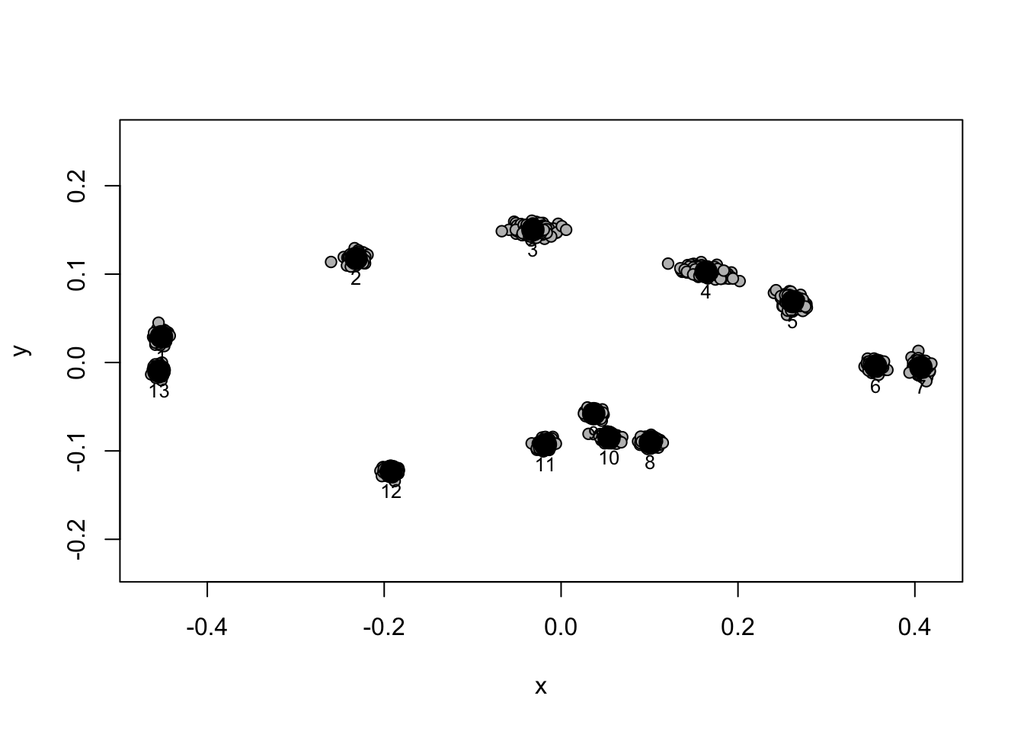

```r
# vendo os espécimes machos e fêmeas:
plotAllSpecimens(A = asas.sobrepo$coords, label = T)
```

PCA

```r
#PCA
data.quase.tudo1 <- asas.sobrepo$coords #passando para outro objeto
tudo1 <- two.d.array(data.quase.tudo1)
tudo1 <- scale(tudo1, scale = FALSE)
p1 <- dim(tudo1)[2]
Nspec <- dim(tudo1)[1]
uns <- rep(1, dim(tudo1)[1])

#calculando as matrizes de covariância (com o produto interno)...
W <- t(tudo1) %*% tudo1 * (Nspec - 1)^-1 #para extrair autovetores X=ZLZ'

eigC <- eigen(W) #e1=t(e11,e12) é o primeiro autovetor dos escores quadrados do pooled
W.PCA <- tudo1 %*% eigC$vectors #ESCORES DE PCA
eigC$vectors #AUTOVETORES
```

```
##                [,1]        [,2]         [,3]         [,4]         [,5]
##  [1,]  8.289561e-05 -0.06693298 -0.055442367 -0.023452625 -0.256822010
##  [2,]  6.812829e-02 -0.06351259  0.284571857  0.105063608  0.105305012
##  [3,]  5.354463e-02 -0.08260534  0.372228553  0.092416757 -0.085940228
##  [4,]  3.794342e-02 -0.11544518 -0.018787082 -0.144027730 -0.027059447
##  [5,]  1.089559e-01  0.90539815 -0.026924886 -0.015456692  0.205634070
##  [6,]  1.109769e-02 -0.02539338 -0.276989064 -0.194756084 -0.106449932
##  [7,] -9.206267e-01  0.03356073 -0.006927934 -0.064969109 -0.014786869
##  [8,]  1.516523e-01  0.06527209 -0.188289678  0.024193853 -0.120262946
##  [9,]  7.267546e-02 -0.10417472 -0.319566088  0.722452846  0.065477842
## [10,]  2.142130e-02  0.15270164  0.202388912 -0.202056419 -0.189663582
## [11,]  1.275711e-01  0.02707111 -0.103955410  0.062666494 -0.383939581
## [12,] -4.001505e-02  0.05788641  0.232005197  0.192051454  0.103660462
## [13,]  1.422362e-01 -0.03279049  0.315962452 -0.206890003 -0.392140639
## [14,] -1.320299e-01  0.00138949  0.356089160  0.312054337  0.128807449
```

[output cut: 147 more lines]

### Quantidade de variância em cada eixo:

```r
#The proportion of the total sum of squares accounted for by the first principal component:
TSS <- 0
for (i in 1:dim(W.PCA)[2]){
  TSS[i] <- round((100 * eigC$values[i] / sum(eigC$values)), 4)
}
TSS # em porcentagem
```

```
##  [1] 27.0756 22.2037  8.5311  7.1438  6.7699  6.0813  3.9478  3.2734
##  [9]  2.5389  2.3910  2.2153  1.5945  1.2737  1.1049  0.9288  0.7634
## [17]  0.5722  0.4851  0.3851  0.3144  0.2435  0.1625  0.0000  0.0000
## [25]  0.0000  0.0000
```

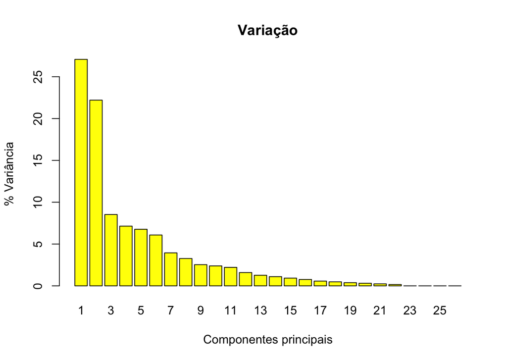

```r
#fazendo o histograma:
PCs <- c(seq(1:dim(W.PCA)[2]))
barplot(TSS[1:dim(W.PCA)[2]], names.arg = PCs, main = 'Variação', xlab = 'Componentes principais', ylab = '% Variância', col = 'yellow')
```

Gráfico de uma PCA, com os eixos 1 (PC1) e 2 (PC2):

[figure not shown]

```r
#plotando...
limite.x1 <- c(min(W.PCA[,1]), max(W.PCA[,1])) #PC1
limite.y2 <- c(min(W.PCA[,2]), max(W.PCA[,2]) + 0.01) #PC2

sexo <- c(rep('M', 78), rep('F', 60))
sexo <- as.factor(sexo)
plot(W.PCA[,1:2], pch = 21, bg = (1:2)[sexo], xlim = limite.x1, ylim = limite.y2,
     main = "Exploring groups in multivariate data", xlab= "Principal component 1", ylab="Principal component 2")

text(W.PCA[,1:2], labels = seq(1:nrow(W.PCA)), cex = 0.6, pos = 3) #para colocar o número de cada
# indivíduo
texto <- c('Machos', 'Fêmeas')
legend('bottomleft', texto, pch = 21, pt.bg = c('black', 'red'))
```

### Agora, vamos aplicar a função *thin-plate spline* no contorno geral de uma asa e nos marcos!

1. Fazer o contorno e deixar os espaços para os marcos:

```r
# visualizando as formas num eixo de PCA:
marcos.asas <- read.table(file = '~/Dropbox/aulas/Morfogeo/morfo_aulas/dados/landmarks28_11_17.txt',
                          sep = '', dec = '.')
semi.asas <- read.table(file = '~/Dropbox/aulas/Morfogeo/morfo_aulas/dados/semimar28_11_17.txt',
                        sep = '', dec = '.')
X<-c(marcos.asas[,1],NA,semi.asas[2:11,1],NA,semi.asas[13:22,1],NA,semi.asas[24:33,1],
     NA,semi.asas[35:42,1],NA,semi.asas[44:51,1],NA,semi.asas[53:72,1],NA,semi.asas[74:88,1],
     NA,semi.asas[90:99,1],NA,semi.asas[101:110,1],NA,semi.asas[112:114,1],NA,semi.asas[116:118,1],
     NA,semi.asas[120:134,1],NA,semi.asas[136:140,1],semi.asas[142:161,1],
     semi.asas[163:166,1])
Y<-c(marcos.asas[,2],NA,semi.asas[2:11,2],NA,semi.asas[13:22,2],NA,semi.asas[24:33,2],
     NA,semi.asas[35:42,2],NA,semi.asas[44:51,2],NA,semi.asas[53:72,2],NA,semi.asas[74:88,2],
     NA,semi.asas[90:99,2],NA,semi.asas[101:110,2],NA,semi.asas[112:114,2],NA,semi.asas[116:118,2],
     NA,semi.asas[120:134,2],NA,semi.asas[136:140,2],semi.asas[142:161,2],
     semi.asas[163:166,2])
molde.asa<-cbind(X,Y)
molde.asa #molde da asa
```

```
##          X   Y
##   [1,] 271 440
##   [2,] 456 502
##   [3,] 619 528
##   [4,] 721 487
##   [5,] 864 452
##   [6,] 943 392
##   [7,] 981 386
##   [8,] 728 326
##   [9,] 674 352
##  [10,] 681 334
##  [11,] 619 323
##  [12,] 485 307
##  [13,] 271 407
##  [14,]  NA  NA
```

[output cut: 163 more lines]

```r
library(shapes);library(geomorph)
forma.media <- mshape(asas.sobrepo$coords)
LM=c(1,12,23,34,43,52,73,100,111,119,135,141,165) #posições dos marcos no molde.asas
```

2. Deformar usando como referência o **molde** e como alvo a **forma média**:

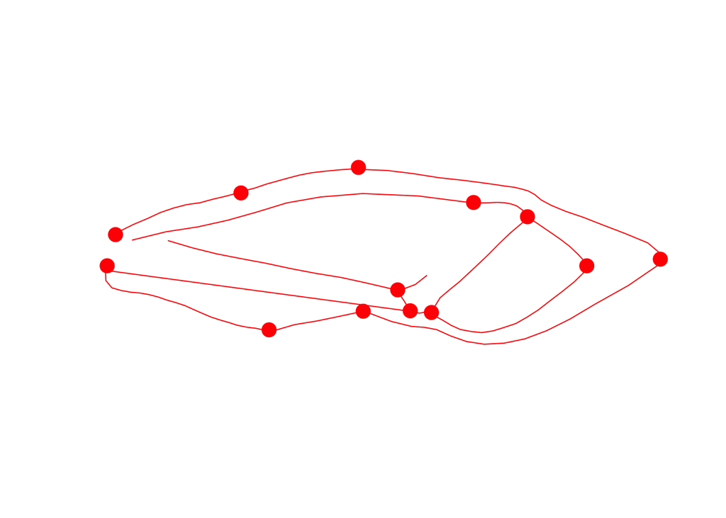

```r
#interpolando o molde para o espaço curvo de Kendall:
LM.forma.media <- forma.media #marcos da forma média
LM.molde <- molde.asa[1:length(LM),] #marcos do molde

#install.packages('Morpho') #pacote que apresenta a função tps3d
library(Morpho)
#deformando...
deforma <- tps3d(x = molde.asa[-(1:length(LM)),], refmat = molde.asa[1:length(LM),],
               tarmat = LM.forma.media) #forma interpolada para o espaço de Kendall


#transformando o escore do eixo 1 (PC1) de uma PCA em uma forma:
scale.factor1 <- -0.08
preditor1 <- as.matrix(eigC$vectors[,1]) * scale.factor1
forma.PCA1 <- matrix(preditor1, dim(LM.forma.media)[1], dim(LM.forma.media)[2]) + forma.media

scale.factor2 <- 0.10
preditor2 <- as.matrix(eigC$vectors[,1]) * scale.factor2
forma.PCA2 <- matrix(preditor2, dim(LM.forma.media)[1], dim(LM.forma.media)[2]) + forma.media

#forma mínima:
deforma.PC <- list()
deforma.PC[[1]] <- tps3d(x = deforma, refmat = LM.forma.media, tarmat = forma.PCA1)

plot(forma.PCA1[,1:2], type = 'n', asp = 1, xlab = '', ylab = '', frame = F, axes = F, ylim = c(min(forma.PCA1[,2], na.rm = T), max(forma.PCA1[,2], na.rm = T)),
     xlim = c(min(forma.PCA1[,1], na.rm = T), max(forma.PCA1[,1], na.rm = T)))
points(forma.PCA1, col = 'red', pch = 19, cex = 1.8)
lines(deforma.PC[[1]],col = 'red')
```

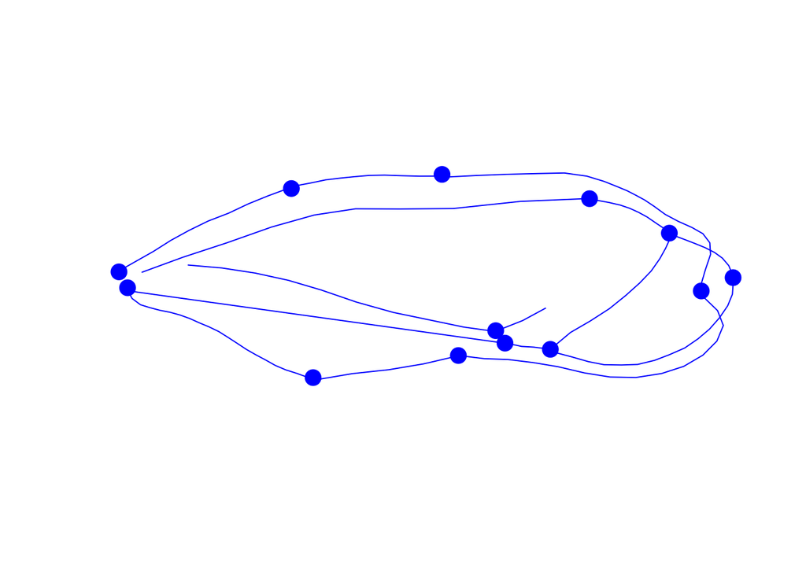

```r
#forma máxima:
deforma.PC[[2]] <- tps3d(x = deforma, refmat = LM.forma.media, tarmat = forma.PCA2)

plot(forma.PCA2[, 1:2], asp = 1, type = 'n', xlab = '', ylab = '', frame = F, axes = F, ylim = c(min(forma.PCA2[,2], na.rm = T), max(forma.PCA2[,2], na.rm = T)),
     xlim = c(min(forma.PCA2[,1], na.rm = T), max(forma.PCA2[,1], na.rm = T)))
points(forma.PCA2, col = 'blue', pch = 19, cex = 1.8)
lines(deforma.PC[[2]],col='blue')
```

### Agora que temos uma ideia da variação, podemos ver se machos se separam de fêmeas.

Para tanto, temos que aplicar a ideia de **aprendizagem supervisionada**: 1) com a função linear discriminante (*LDA*)

```r
# computation of LDA (discrimination)
#install.packages('MASS')
library(MASS)
tudo.PCA <- as.data.frame(W.PCA)
tudo.PCA$sexo <- sexo
head(tudo.PCA)
```

```
##                 V1           V2            V3           V4           V5
## male1 -0.001349385  0.002937303  0.0005802964  0.003895709  0.001690715
## male2  0.008563227  0.009555383 -0.0076405236 -0.006712210 -0.006320949
## male3 -0.005580815 -0.020721385  0.0082790367  0.005672231 -0.003769684
## male4  0.016633657  0.001976557 -0.0038731486  0.014474505  0.001519751
## male5 -0.009141541  0.006834623 -0.0043970004 -0.010868551 -0.011745444
## male6 -0.014298451 -0.001375857  0.0206413552  0.018095749  0.004028879
##                  V6           V7           V8            V9          V10
## male1  0.0003984064  0.005676281 -0.001295470  0.0004692447 -0.001360847
## male2  0.0019906003 -0.007907342  0.006111069 -0.0005728259 -0.001606074
## male3 -0.0052149030 -0.004918530  0.001182179 -0.0024453433 -0.002524534
## male4  0.0062076107  0.001333979  0.001479723  0.0048934587 -0.001310951
## male5  0.0039225719 -0.006820678  0.003831353  0.0028719492 -0.005101690
## male6 -0.0051130052  0.013542512 -0.006717330 -0.0045106474  0.015311424
##                 V11           V12           V13           V14
## male1  0.0009390762 -0.0019410503 -0.0022160416 -0.0022614099
## male2 -0.0045830807 -0.0015451738 -0.0009945202 -0.0043674659
## male3  0.0091921212  0.0007959395  0.0017056114  0.0090095828
## male4  0.0050578628 -0.0035350211 -0.0028128255  0.0022499224
## male5  0.0060942508  0.0031419311 -0.0022895507 -0.0003757641
## male6  0.0055611743  0.0090085758 -0.0065410130 -0.0038673829
##                 V15           V16           V17           V18
## male1  0.0005411994  0.0008333412  0.0008077636  0.0003403667
## male2 -0.0008568068 -0.0029036919 -0.0028757771  0.0055573581
## male3 -0.0018651441 -0.0069563357  0.0022308270 -0.0026731886
## male4  0.0010289940 -0.0011511701  0.0032538960 -0.0007844240
## male5 -0.0002039872  0.0027391675  0.0039871979  0.0014939408
## male6  0.0004304879  0.0054274575 -0.0029415686  0.0027494776
##                 V19           V20           V21           V22
## male1 -0.0013557339  0.0010524284 -1.401631e-03  1.468290e-03
## male2 -0.0026927178 -0.0001329957 -1.407381e-04  3.929690e-04
## male3  0.0012541892  0.0010717645  4.619031e-05  1.572724e-04
## male4 -0.0015377929  0.0013030695  1.867955e-03 -2.362767e-03
## male5 -0.0008716742  0.0001249403  9.238343e-04 -3.566091e-05
## male6  0.0017616796  0.0002234898 -6.929567e-04 -7.762821e-04
##                 V23           V24           V25           V26 sexo
## male1 -5.653437e-17  1.113476e-16  8.751544e-18 -3.933621e-17    M
## male2 -7.665309e-17  7.372575e-18  8.131516e-18 -1.561251e-17    M
## male3 -2.986977e-17  4.938541e-17  2.501797e-17 -8.402567e-18    M
## male4  5.529431e-18  5.963112e-17 -1.626303e-18 -4.401861e-17    M
## male5 -3.773024e-17 -8.673617e-18 -1.149254e-17 -3.924812e-17    M
## male6 -3.447763e-17 -8.760354e-17 -6.494371e-17  2.797242e-17    M
```

```r
#usando a função lda
asas.lda <- lda(sexo~., data = tudo.PCA[,-c(23:26)])

# classificando os objetos
asas.class <- predict(asas.lda)$class
asas.class
```

```
##   [1] F F M M M M M M M M M M M M M M M M M F M M M M M M F M M M M M M M M
##  [36] M M M M M M M M M M M M M M M M M M M M M M M M M M M M M M M M M M M
##  [71] F M M M M M M M F M F F M F F F F F F F F F F F F F M F F F F F M F F
## [106] F F F F F F F F F F F M F F F M F F F F F F F F F F F F F F F F F
## Levels: F M
```

```r
# plot of objects in the space of the canonical variates with colours according to their classification
F.mat <- predict(asas.lda)$x #position of the object in the space of the canonical variates
F.mat <- as.data.frame(F.mat)
F.mat$sexo <- tudo.PCA$sexo
F.mat
```

```
##                  LD1 sexo
## male1    -0.71851474    M
## male2    -0.87151182    M
## male3     1.94733107    M
## male4     0.27110099    M
## male5     0.15167609    M
## male6     0.23165287    M
## male7     0.97999743    M
## male8     2.37715438    M
## male9     2.18750878    M
## male10    0.07078045    M
## male11    0.39266122    M
## male12    1.85374311    M
## male13    1.29706465    M
## male14    1.07175927    M
## male15    0.08804792    M
## male16    0.41490047    M
## male17    0.30138799    M
## male18    0.07193495    M
## male19    2.12890110    M
## male20   -0.49177814    M
## male21    2.98507179    M
## male22    1.90990092    M
## male23    0.78670564    M
## male24    3.34412841    M
## male25    1.29272469    M
## male26    1.39356344    M
## male27   -0.76270807    M
## male28    0.27397410    M
## male29    0.52720350    M
## male30    1.67530490    M
## male31    2.46853575    M
## male32    2.56756485    M
## male33    1.76485910    M
## male34    0.93066008    M
## male35    0.35393309    M
## male36    1.27681584    M
## male37    1.48656255    M
## male38    0.46817782    M
## male39    0.76381025    M
```

[output cut: 84 more lines]

```
## female46 -1.46588434    F
## female47 -0.60814859    F
## female48 -1.69919566    F
## female49 -2.46451865    F
## female50 -1.50945620    F
## female51 -1.65584721    F
## female52 -1.90154821    F
## female53 -1.02599230    F
## female54 -2.99753200    F
## female55 -0.71963128    F
## female56 -2.53262436    F
## female57 -2.74674063    F
## female58 -2.05463056    F
## female59 -3.40521729    F
## female60 -1.00615179    F
```

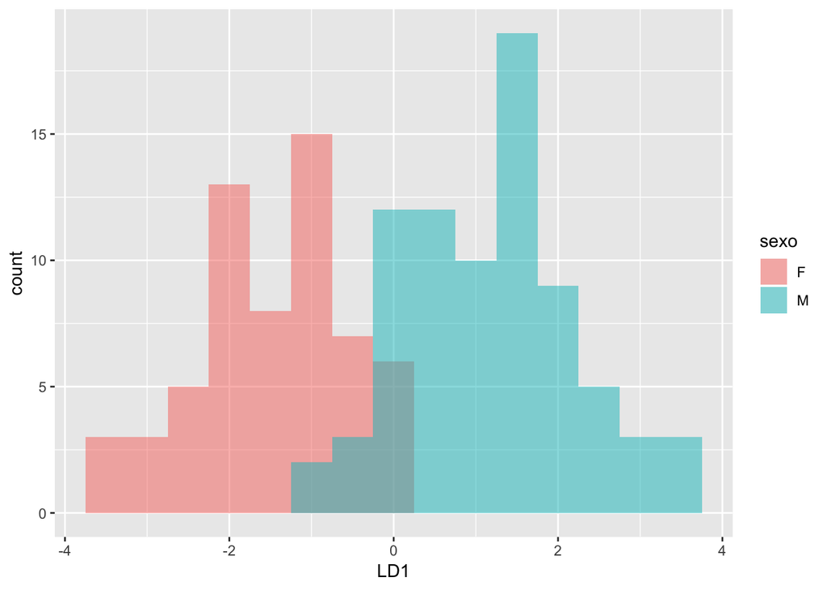

```r
#histograma:
#install.packages('ggplot2')
library(ggplot2)
# Overlaid histograms
ggplot(F.mat, aes(x=LD1, fill=sexo)) +
  geom_histogram(binwidth=.5, alpha=.5, position="identity")
```

Colocando histogramas com médias:

```r
# com a função aggregate
?aggregate
cdat <- aggregate(LD1 ~ sexo, data = F.mat, mean)
cdat #médias
```

```
##   sexo       LD1
## 1    F -1.490058
## 2    M  1.146198
```

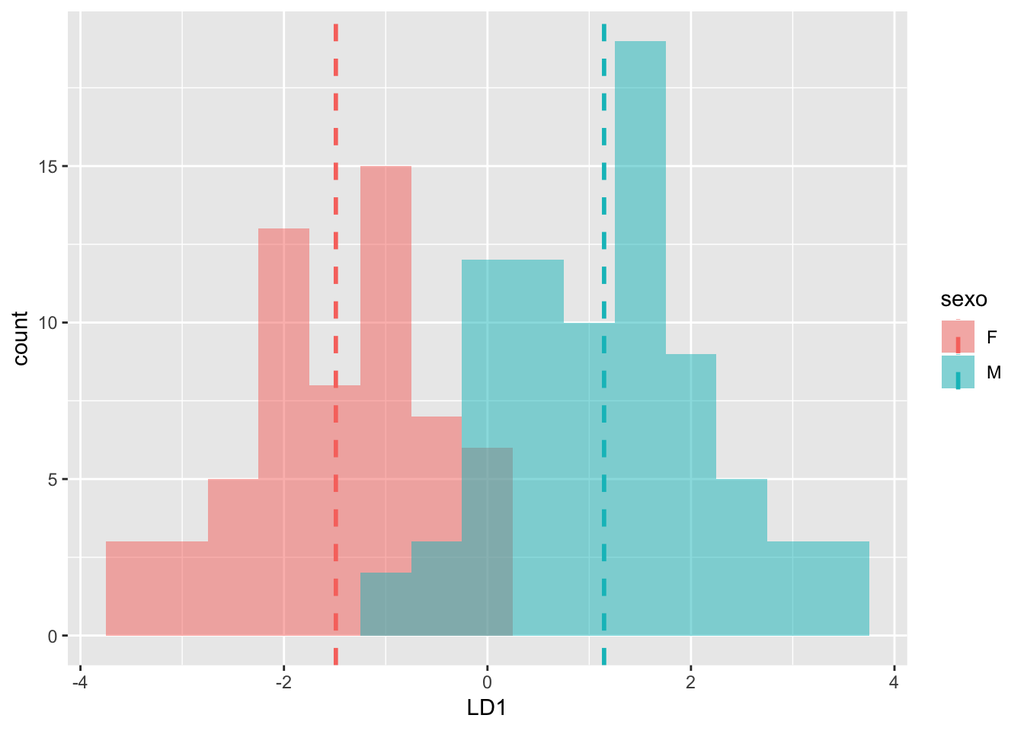

```r
ggplot(F.mat, aes(x=LD1, fill=sexo)) +
  geom_histogram(binwidth=.5, alpha=.5, position="identity") +
  geom_vline(data=cdat, aes(xintercept=LD1,  colour=sexo),
             linetype="dashed", size=1)
```

$\color{red}{\text{Portanto, podemos dizer que existe alguma diferença entre machos e fêmeas!}}$

### $\color{blue}{\text{Vamos saber quanto de diferença existe?}}$

```r
#posterior probabilities of objects belonging to the groups
asas.post <- predict(asas.lda)$posterior
asas.post
```

```
##                     F            M
## male1    7.646913e-01 0.2353087142
## male2    8.294753e-01 0.1705246684
## male3    2.873694e-03 0.9971263062
## male4    1.930509e-01 0.8069491358
## male5    2.468521e-01 0.7531479061
## male6    2.097701e-01 0.7902298728
## male7    3.560071e-02 0.9643992854
## male8    9.272092e-04 0.9990727908
## male9    1.527721e-03 0.9984722789
## male10   2.885964e-01 0.7114035730
## male11   1.479500e-01 0.8520500056
## male12   3.674865e-03 0.9963251354
## male13   1.575046e-02 0.9842495446
## male14   2.816660e-02 0.9718333980
## male15   2.793411e-01 0.7206588581
## male16   1.407107e-01 0.8592892504
## male17   1.809164e-01 0.8190836162
## male18   2.879720e-01 0.7120280391
## male19   1.782518e-03 0.9982174823
## male20   6.412602e-01 0.3587397764
## male21   1.868477e-04 0.9998131523
## male22   3.170774e-03 0.9968292260
## male23   5.789024e-02 0.9421097600
## male24   7.251859e-05 0.9999274814
## male25   1.592881e-02 0.9840711920
## male26   1.225603e-02 0.9877439733
## male27   7.850056e-01 0.2149944058
## male28   1.918737e-01 0.8081263277
## male29   1.085674e-01 0.8914326153
## male30   5.869212e-03 0.9941307884
## male31   7.288537e-04 0.9992711463
## male32   5.614790e-04 0.9994385210
## male33   4.640710e-03 0.9953592896
## male34   4.034626e-02 0.9596537386
## male35   1.612883e-01 0.8387116993
## male36   1.659974e-02 0.9834002594
## male37   9.616849e-03 0.9903831512
## male38   1.245695e-01 0.8754305024
## male39   6.127131e-02 0.9387286941
```

[output cut: 84 more lines]

```
## female46 9.588627e-01 0.0411373348
## female47 7.083989e-01 0.2916011372
## female48 9.773326e-01 0.0226673784
## female49 9.969254e-01 0.0030746407
## female50 9.631622e-01 0.0368377633
## female51 9.746580e-01 0.0253420236
## female52 9.865781e-01 0.0134219179
## female53 8.796546e-01 0.1203453816
## female54 9.992440e-01 0.0007560492
## female55 7.652205e-01 0.2347794817
## female56 9.974294e-01 0.0025706258
## female57 9.985366e-01 0.0014634452
## female58 9.909949e-01 0.0090051048
## female59 9.997418e-01 0.0002582277
## female60 8.740067e-01 0.1259933456
```

```r
#Confusion matrix
asa.table <- table(tudo.PCA$sexo, asas.class)
asa.table
```

```
##    asas.class
##      F  M
##   F 54  6
##   M  5 73
```

```r
#Percentage of correct classification
diag(prop.table(asa.table, 1))
```

```
##         F         M
## 0.9000000 0.9358974
```

```r
#miss-classification error (sem LOOCV)
#matriz de confusao:
erro.asa <- 1 - sum(diag(asa.table)) / sum(asa.table) #erro interno sem LOOCV
erro.asa #erro = 0.07971014
```

```
## [1] 0.07971014
```

$\color{red}{\text{Temos então uma taxa de erro em torno de 7.97%! Mas isso é o erro interno (ou misclassification internal error)!}}$

Precisamos obter o erro de classificação com **novos dados**! Para tanto, iremos usar uma das formas de obter dados novos: o *Leave-one-out cross-validation* (LOOCV):

```r
#LDA with jackknife-based classification (LOOCV)
asas.lda.jac <- lda(sexo~., data = tudo.PCA[,-c(23:26)], CV = TRUE)

# Number and percentages of correct classification
asas.lda.jac.class <- asas.lda.jac$class
asas.jac.table <- table(tudo.PCA$sexo, asas.lda.jac.class)
asas.jac.table
```

```
##    asas.lda.jac.class
##      F  M
##   F 48 12
##   M 15 63
```

```r
diag(prop.table(asas.jac.table, 1))
```

```
##         F         M
## 0.8000000 0.8076923
```

```r
#miss-classification error (com LOOCV)
#matriz de confusao:
erro.asas.jack <- 1 - sum(diag(asas.jac.table)) / sum(asas.jac.table) #erro interno com LOOCV
erro.asas.jack #erro = 0.1956522
```

```
## [1] 0.1956522
```

$\color{red}{\text{A taxa de erro aumentou para cerca de 19.6%! Isso significa que houve um overfitting do modelo! Esse processo é chamado de validação externa!}}$

### Podemos ainda ver as formas associadas aos valores médios da função linear discriminante:

```r
molde.asa #molde da asa
```

```
##          X   Y
##   [1,] 271 440
##   [2,] 456 502
##   [3,] 619 528
##   [4,] 721 487
##   [5,] 864 452
##   [6,] 943 392
##   [7,] 981 386
##   [8,] 728 326
##   [9,] 674 352
##  [10,] 681 334
##  [11,] 619 323
##  [12,] 485 307
##  [13,] 271 407
##  [14,]  NA  NA
```

[output cut: 163 more lines]

```r
library(shapes);library(geomorph)

forma.media <- mshape(asas.sobrepo$coords)
LM=c(1:13)

#interpolando o molde para o espaço curvo de Kendall:
LM.forma.media <- forma.media #marcos da forma média
LM.molde <- molde.asa[1:length(LM),] #marcos do molde

#Calculate averaged shapes for each species
library(shapes)
asas.a
```

[output not shown]

[output cut: 2330 more lines]

```r
teste <- procGPA(asas.a)
```

```
## [1] "To speed up use option distances=FALSE"
## [1] "To speed up use option pcaoutput=FALSE"
```

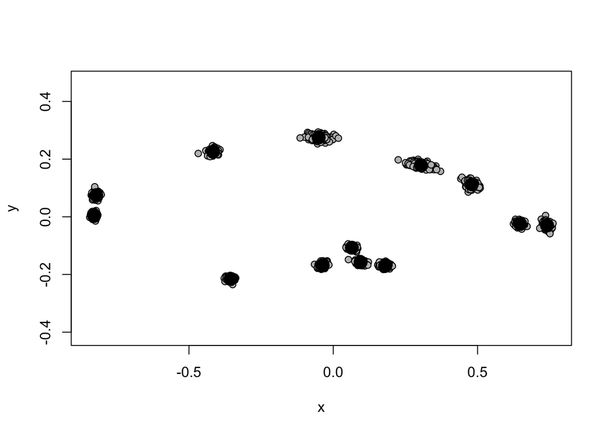

```r
plotAllSpecimens(teste$rotated)
```

```r
VDP <- teste$tan #formas projetadas no espaço tangente
m <- t(matrix(VDP, 13 * 2, 138))
m
```

```
##                 [,1]          [,2]          [,3]          [,4]
##   [1,] -4.932625e-03 -1.621097e-03  5.063531e-03  9.488239e-04
##   [2,]  2.777815e-03 -1.798255e-03  1.466396e-02 -9.441449e-03
##   [3,]  4.070317e-03  1.932729e-02 -3.675847e-02  7.329108e-03
##   [4,]  8.782252e-04  4.719292e-03  8.291098e-03 -3.089123e-02
##   [5,]  5.810328e-03 -2.119803e-03  7.219508e-03  1.719227e-02
##   [6,] -7.648619e-03  1.838749e-02 -3.729189e-03  1.857651e-02
##   [7,]  6.312148e-03 -3.619218e-03 -1.831555e-02 -1.095709e-02
##   [8,]  1.221536e-04  1.793461e-03 -9.498583e-03 -1.479230e-02
##   [9,]  7.255186e-03 -1.089771e-02 -2.219271e-02  2.329585e-02
##  [10,]  5.984838e-03 -1.580515e-02  5.242965e-02  2.237286e-02
##  [11,] -2.844235e-03 -1.148199e-02  2.018834e-02 -3.419127e-03
##  [12,]  1.056908e-02  5.324346e-04 -3.402578e-02  4.090479e-02
##  [13,] -6.252487e-03  4.888291e-03 -2.795130e-02  3.208537e-02
##  [14,]  5.778719e-03 -1.791062e-03 -3.010854e-02  2.245876e-02
```

[output cut: 958 more lines]

```r
#usando a função lda
dados <- two.d.array(asas.sobrepo$coords)
head(dados)
```

```
##             [,1]       [,2]       [,3]      [,4]        [,5]      [,6]
## male1 -0.4542407 0.03019569 -0.2323275 0.1147648 -0.02900286 0.1474478
## male2 -0.4501247 0.02730446 -0.2325973 0.1175968 -0.02393259 0.1545140
## male3 -0.4497059 0.03210448 -0.2212314 0.1231592 -0.05209866 0.1518747
## male4 -0.4513212 0.03073796 -0.2290829 0.1187641 -0.02725832 0.1479044
## male5 -0.4485068 0.02766423 -0.2329460 0.1233792 -0.02814317 0.1591402
## male6 -0.4566689 0.03791333 -0.2216411 0.1121713 -0.03362756 0.1381547
##            [,7]       [,8]      [,9]      [,10]     [,11]         [,12]
## male1 0.1643812 0.09947340 0.2635624 0.06662837 0.3560033 -0.0032480753
## male2 0.1583750 0.11359375 0.2615150 0.07625527 0.3555974 -0.0090496652
## male3 0.1680302 0.09890646 0.2624841 0.06366840 0.3567589  0.0009867135
## male4 0.1468812 0.10392951 0.2755336 0.06008630 0.3558482 -0.0010182308
## male5 0.1732862 0.10305992 0.2547598 0.07069692 0.3549436 -0.0054499147
## male6 0.1744803 0.09387390 0.2622771 0.06621899 0.3591560  0.0008495399
##           [,13]         [,14]      [,15]       [,16]      [,17]
## male1 0.4073396 -0.0028764406 0.09945103 -0.08658864 0.03831934
## male2 0.4077312 -0.0136238222 0.09330754 -0.08908462 0.03813265
## male3 0.4061931 -0.0006476521 0.10321768 -0.09529432 0.02846258
## male4 0.4089375 -0.0031502198 0.09898346 -0.08977096 0.03441367
## male5 0.4114526 -0.0107566459 0.09045596 -0.08904855 0.03326929
## male6 0.4039739  0.0131747194 0.10818083 -0.09324383 0.04078915
##             [,18]      [,19]       [,20]       [,21]       [,22]
## male1 -0.05710563 0.05251129 -0.08460030 -0.01982183 -0.09227804
## male2 -0.06080302 0.05750741 -0.08715477 -0.01805245 -0.09318685
## male3 -0.05830002 0.05699872 -0.09135690 -0.01428300 -0.09265241
## male4 -0.05648619 0.05554024 -0.08310630 -0.02004472 -0.09227179
## male5 -0.05501111 0.05275361 -0.08440478 -0.01557608 -0.09374658
## male6 -0.06101078 0.03102783 -0.08072570 -0.02090057 -0.09629925
##            [,23]      [,24]      [,25]        [,26]
## male1 -0.1908676 -0.1217931 -0.4553076 -0.010019859
## male2 -0.1945633 -0.1213428 -0.4528959 -0.015018729
## male3 -0.1866180 -0.1236685 -0.4582083 -0.008780094
## male4 -0.1926318 -0.1218796 -0.4557989 -0.013739009
## male5 -0.1939370 -0.1255710 -0.4518120 -0.019951937
## male6 -0.1882983 -0.1269146 -0.4587488 -0.004162360
```

```r
dados <- as.data.frame(dados)

asas.lda <- lda(sexo~., data = dados)
asas.lda
```

```
## Call:
## lda(sexo ~ ., data = dados)
##
## Prior probabilities of groups:
##         F         M
## 0.4347826 0.5652174
##
## Group means:
##           V1         V2         V3        V4         V5        V6
## F -0.4532774 0.03010594 -0.2307019 0.1163657 -0.0261316 0.1483245
## M -0.4507211 0.02846858 -0.2324322 0.1186479 -0.0362924 0.1517035
##          V7        V8        V9        V10       V11          V12
## F 0.1600397 0.1030183 0.2606099 0.07082348 0.3563581 -0.003113831
## M 0.1668635 0.1023458 0.2628077 0.06735888 0.3549042 -0.004545364
##         V13          V14        V15         V16        V17         V18
## F 0.4077740 -0.005151581 0.09961195 -0.09079001 0.03601513 -0.05711730
## M 0.4060659 -0.005568403 0.10192426 -0.08999273 0.03760051 -0.05847883
##          V19         V20         V21         V22        V23        V24
## F 0.05505432 -0.08519358 -0.01795991 -0.09443184 -0.1923190 -0.1240306
## M 0.05359472 -0.08499212 -0.01760400 -0.09144759 -0.1922125 -0.1229361
##          V25          V26
## F -0.4550733 -0.008809259
## M -0.4544986 -0.010563579
##
## Coefficients of linear discriminants:
##             LD1
## V1   194.864884
## V2   -73.543185
## V3   -18.404598
## V4   174.568237
## V5   -26.096781
## V6    -7.112171
## V7    18.141069
## V8   -35.343593
## V9    34.807354
## V10  -32.288289
## V11  -19.934299
## V12  -17.623256
## V13  -20.760897
## V14   14.102624
## V15   38.238508
## V16   11.773982
## V17    9.141053
## V18 -181.936937
## V19  -43.042579
## V20   20.556010
## V21  -56.949361
## V22  214.089972
## V23   24.063491
## V24  -84.865269
## V25 -103.234355
## V26  -17.472588
```

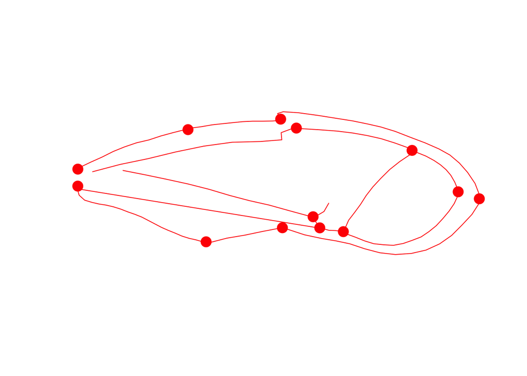

```r
LD.as <- asas.lda$scaling

#the within group variance-covariance
modelo1 <- lm(m ~ sexo)
n <- dim(m)[1]
dfw <- n - length(levels(sexo))
SSw <- var(modelo1$residuals) * (n - 1)
VCVw <- SSw / dfw
LDs <- VCVw %*% LD.as

#deformando...
library(Morpho)
scale.factor.f <- -1.4
preditores1 <- as.matrix(LDs[,1]) * scale.factor.f #para fêmeas
forma.LD1 <- matrix(preditores1, dim(forma.media)[1], dim(forma.media)[2]) + forma.media

scale.factor.m <- 1.0
preditores2 <- as.matrix(LDs[,1]) * scale.factor.m #para machos
forma.LD2 <- matrix(preditores2, dim(forma.media)[1], dim(forma.media)[2]) + forma.media

deforma <- tps3d(x = molde.asa[-(1:length(LM)),], refmat = molde.asa[1:length(LM),], tarmat = LM.forma.media)

deforma.PC <- list()
deforma.PC[[1]] <- tps3d(x = deforma, refmat = LM.forma.media, tarmat = as.matrix(forma.LD1[LM,]))
deforma.PC[[2]] <- tps3d(x = deforma, refmat = LM.forma.media, tarmat = as.matrix(forma.LD2[LM,]))

#forma mínima
plot(forma.LD1[,1:2], type = "n", asp = 1, xlab = "", ylab = "", frame = F, axes = F,
     ylim = c(min(forma.LD1[,2], na.rm = T), max(forma.LD1[,2], na.rm = T)),
     xlim = c(min(forma.LD1[,1], na.rm = T), max(forma.LD1[,1], na.rm = T)))
points(forma.LD1[LM, 1:2], col = 'red', pch = 19, cex = 1.8)
lines(deforma.PC[[1]], col = 'red')
```

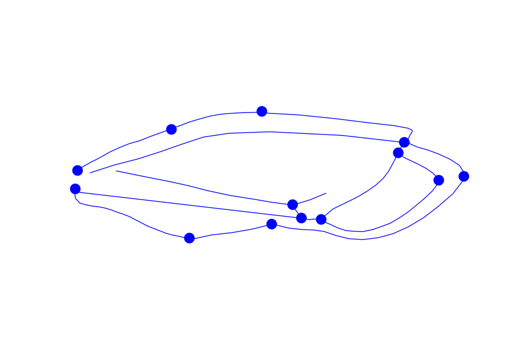

```r
#forma máxima
plot(forma.LD2[,1:2], type = "n", asp = 1, xlab = "", ylab = "", frame = F, axes = F,
     ylim = c(min(forma.LD2[,2], na.rm = T), max(forma.LD2[,2], na.rm = T)),
     xlim = c(min(forma.LD2[,1], na.rm = T), max(forma.LD2[,1], na.rm = T)))
points(forma.LD2[LM, 1:2], col = 'blue', pch = 19, cex = 1.8)
lines(deforma.PC[[2]],col = 'blue')
```

### Prodemos ainda saber qual é a distância entre essas formas… **Uma distância muito útil é a distância de Mahalanobis. Ela mede a distância do centro de um *grão* ao outro!**

```r
#Compute the Mahalanobis distance among the three species
m.dm <- asas.lda$means
m.dm.proj <- m.dm %*% asas.lda$scaling
dist.obs <- dist(m.dm.proj) #distances between mean groups in the space defined by discriminant functions

dist(predict(asas.lda, as.data.frame(m.dm))$x)
```

```
##          F
## M 2.636256
```

```r
#        f
#m  2.636256

# Lembrem-se...
asas.a <- arrayspecs(A = asas, p = 13, k = 2) #convertendo em array

#calcular p-valores (the null hypothesis of equal group means):
dist.permu <- 0
for (vo in 1:10){
  tudo1 <- asas[1:78,]
  tudo2 <- asas[79:138,]
  m.modif <- tudo1[sample(nrow(tudo1)),]  #the permuted landmark matrix of one sex
  f.modif <- tudo2[sample(nrow(tudo2)),] #the permuted landmark matrix of one sex
  data.tudo <- rbind(m.modif, f.modif)
  asas.modif <- arrayspecs(A = data.tudo, p = 13, k = 2) #convertendo em array
  tudo.sobrepo.modif <- gpagen(A = asas.modif, ProcD = T, print.progress = F)

  #PCA
  data.quase.tudo1 <- tudo.sobrepo.modif$coords #passando para outro objeto
  t1 <- two.d.array(data.quase.tudo1)
  t1 <- scale(t1, scale = FALSE)
  p1 <- dim(t1)[2]
  Nspec <- dim(t1)[1]
  uns <- rep(1, dim(t1)[1])

  #calculando as matrizes de covariância (com o produto interno)...
  W <- t(t1) %*% t1 * (Nspec - 1)^-1 #para extrair autovetores X=ZLZ'

  eigC <- eigen(W)
  W.PCA <- t1 %*% eigC$vectors #ESCORES DE PCA

  asas.fd.modif <- as.data.frame(W.PCA)
  asas.lda.modif <- lda(sexo~., data = asas.fd.modif[,-c(23:26)])

  #Compute the Mahalanobis distance among the sexes (amostras)
  m.dm <- asas.lda.modif$means
  m.dm.proj <- m.dm %*% asas.lda.modif$scaling
  dist.permu[i] <- dist(m.dm.proj) #distances between mean groups in the space defined by discriminant functions
}
total <- sum(ifelse(dist.permu >= dist.obs, 1, 0), na.rm = T)
pvalor <- total / 10000
pvalor
```

```
## [1] 1e-04
```

[figure not shown]

**Hipótese 1: integração entre membrana e cório.**

### Correlação e integração entre partes, ou estruturas, ou blocos de variáveis:

```r
# Estudos de integração
# Two-block Partial Least Squares (2B-PLS): correlação entre singular warps ou vetores singulares
# Essa abordagem permite ver como os grupos de variáveis covariam:
# No geomorph, a função é two.b.pls:
# FIZEMOS UMA SOBREPOSIÇÃO PARA CADA CONFIGURAÇÃO DE PONTOS, AO INVÉS DE UMA PARA TODA A ASA!
#Sobreposição de Procrustes para corio:
corio <- asas.a[c(1, 2, 3, 4, 9, 10, 11, 12, 13),,]
corio.sobrepo <- gpagen(A = corio) #sobreposição de Procrustes
#Sobreposição de Procrustes para membrana:
membrana <- asas.a[c(5, 6, 7, 8),,]
memb.sobrepo <- gpagen(A = membrana)
# O conhecimento acerca da posição relativa e orientação dos módulos é perdido (KLINGENBERG, 2009)!
#######
two.b.pls(corio.sobrepo$coords, memb.sobrepo$coords, iter = 999)
```

```
##
## Call:
## two.b.pls(A1 = corio.sobrepo$coords, A2 = memb.sobrepo$coords,
##     iter = 999)
##
##
##
## r-PLS: 0.307
##
## P-value: 0.048
##
## Based on 1000 random permutations
```

```r
result <- two.b.pls(corio.sobrepo$coords, memb.sobrepo$coords, iter = 999)
names(result)
```

```
##  [1] "r.pls"             "P.value"           "left.pls.vectors"
##  [4] "right.pls.vectors" "random.r"          "XScores"
##  [7] "YScores"           "svd"               "A1"
## [10] "A2"                "A1.matrix"         "A2.matrix"
## [13] "permutations"      "call"              "method"
```

```r
?two.b.pls
round(cor(result$XScores, result$YScores), 2)
```

```
##      [,1] [,2] [,3] [,4]  [,5]  [,6]  [,7]  [,8]
## [1,] 0.31 0.00 0.00 0.00 -0.01  0.01  0.02 -0.06
## [2,] 0.00 0.21 0.00 0.00 -0.01  0.00  0.07 -0.07
## [3,] 0.00 0.00 0.28 0.00  0.00  0.01 -0.03  0.07
## [4,] 0.00 0.00 0.00 0.11 -0.01  0.00  0.03 -0.05
## [5,] 0.00 0.00 0.00 0.00  0.22  0.00  0.04 -0.02
## [6,] 0.00 0.00 0.00 0.00  0.00  0.14  0.09 -0.01
## [7,] 0.00 0.00 0.00 0.00  0.01 -0.01  0.05  0.01
## [8,] 0.00 0.00 0.00 0.00 -0.01  0.00  0.01  0.12
```

### Decomposição de valores singulares é usada quando as matrizes não são quadradas!

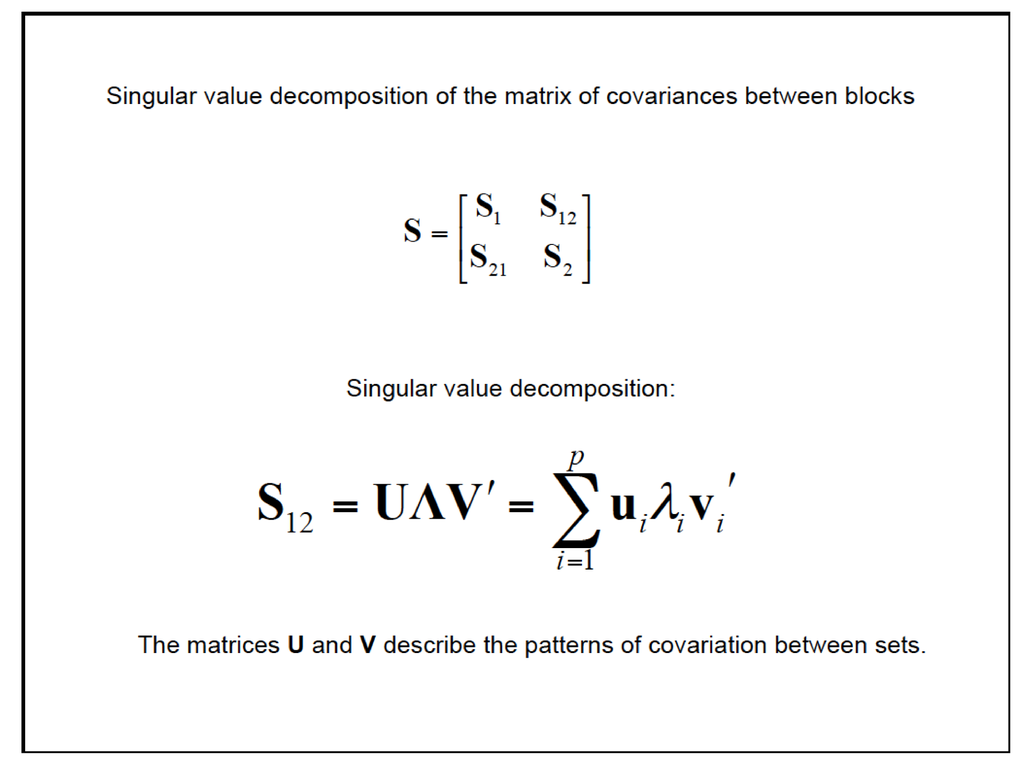

### O coeficiente RV mede **a força geral de covariância entre partes ou módulos**

### e é análogo ao *coeficiente de determinação* em regressão

### $$RV = \frac{tr (\mathbf{S}_{12} \mathbf{S}_{21})} {\sqrt{tr (\mathbf{S_1 S_1^t}) tr (\mathbf{S_2 S_2^t})}}$$

```r
corio.sobrepo$coords; memb.sobrepo$coords
```

[output not shown]

[output cut: 1738 more lines]

```
##  [8,] -0.09109267 -0.19267437
##  [9,] -0.48122632 -0.02104974
##
## , , female60
##
##              [,1]        [,2]
##  [1,] -0.46933532  0.03868414
##  [2,] -0.19695691  0.15804940
##  [3,]  0.14982183  0.21246052
##  [4,]  0.40399183  0.13877027
##  [5,]  0.23891262 -0.08882884
##  [6,]  0.27822495 -0.13355278
##  [7,]  0.15656422 -0.13436801
##  [8,] -0.08702896 -0.17873979
##  [9,] -0.47419425 -0.01247490
```

[output not shown]

[output cut: 1048 more lines]

```
## , , female59
##
##             [,1]        [,2]
## [1,]  0.01638571  0.30295949
## [2,]  0.27481060 -0.07155031
## [3,]  0.46992616 -0.13050303
## [4,] -0.76112246 -0.10090614
##
## , , female60
##
##              [,1]        [,2]
## [1,] -0.006258385  0.30461920
## [2,]  0.294942636 -0.07150799
## [3,]  0.466426404 -0.13848098
## [4,] -0.755110655 -0.09463022
```

```r
tudo1 <- two.d.array(corio.sobrepo$coords)
tudo2 <- two.d.array(memb.sobrepo$coords)
data.tudo<-cbind(tudo1,tudo2)

p1<-dim(tudo1)[2]
p2<-dim(tudo2)[2]
Nspec<-dim(tudo1)[1]
uns<-rep(1,dim(tudo1)[1])

#calculando a matriz de variância-covariância...
Scov<-var(data.tudo)
Sm1m1<-var(tudo1)
Sm2m2<-var(tudo2)
Sm1m2<- Scov[1:p1, (p1 + 1):(p1+p2)] #isolando a parte da matriz S que descreve a covariância entre os blocos 1 e 2
Sm2m1<-Scov[(p1+1):(p1+p2),1:p1]

#decompondo...
Sm1m2.dec<-svd(Sm1m2)
U<-round(Sm1m2.dec$u,8)  #weights for variables in block one
V<-round(Sm1m2.dec$v,8) #weights for variables in block two
D<-round(Sm1m2.dec$d,8) #valores singulares

#Esses escores de PLS são projeções do espaço dos dados originais e, assim, incluem também as diferenças
#de forma entre localidades e/ou táxons
PLS.scores.1<-tudo1%*%U[,1] #Singular warps 1
PLS.scores.2<-tudo2%*%V[,1] #Singular warps 2

#covariância entre os blocos quando pooled...
RV.zeca <- sum(diag(Sm1m2 %*% Sm2m1)) / sqrt(sum(diag(Sm1m1 %*% Sm1m1))
              * sum(diag(Sm2m2 %*% Sm2m2))) #A força de associação entre os fatores
RV.zeca
```

```
## [1] 0.03968988
```

### **_______exercício 10________:**

Qual o *p*-valor desse RV?

```r
#permutation test (RV not different from random samples):
RV.modif <- NULL
simula.cor <- 0
cor.pval <- 0
reps = 10000
for (vo in 1:reps){
  tudo1.modif<-tudo1[sample(nrow(tudo1)),]  #the permuted landmark matrix of one block
  #tudo2.modif<-tudo2[sample(nrow(tudo2)),] #the permuted landmark matrix of one block
  data.tudo.modif<-cbind(tudo1.modif,tudo2)
  #calculando a matriz de variância-covariância modificada...
  Scov.modif<-t(data.tudo.modif) %*% data.tudo.modif * (Nspec - 1) ^ -1
  Sm1m2.modif<- Scov.modif[1:p1, (p1 + 1):(p1+p2)] #isolando a parte da matriz S que descreve a

  #covariância entre os blocos 1 e 2
  Sm2m1.modif <- var(data.tudo.modif)[(p1+1):(p1+p2),1:p1]
  Sm1m1.modif <- var(tudo1.modif)
  Sm2m2.modif <- var(tudo2)
  RV.modif[vo] <- sum(diag(Sm1m2.modif %*% Sm2m1.modif)) /
    sqrt(sum(diag(Sm1m1.modif %*% Sm1m1.modif)) * sum(diag(Sm2m2.modif %*% Sm2m2.modif)))
  Sm1m2.mod.dec <- svd(Sm1m2.modif)
  U.mod <- round(Sm1m2.mod.dec$u,8)  #weights for variables in block one
  V.mod <- round(Sm1m2.mod.dec$v,8) #weights for variables in block two
  D.mod <- round(Sm1m2.mod.dec$d,8) #valores singulares
  fase1.mod <- tudo1.modif%*%U.mod
}

simula <- sum(ifelse(RV.modif >= RV.zeca, 1, 0))
RV.pval <- round(simula / reps, 4) #the tail probability of the RV value
RV.pval #p-valor de RV pooled
```

```
## [1] 0.0895
```

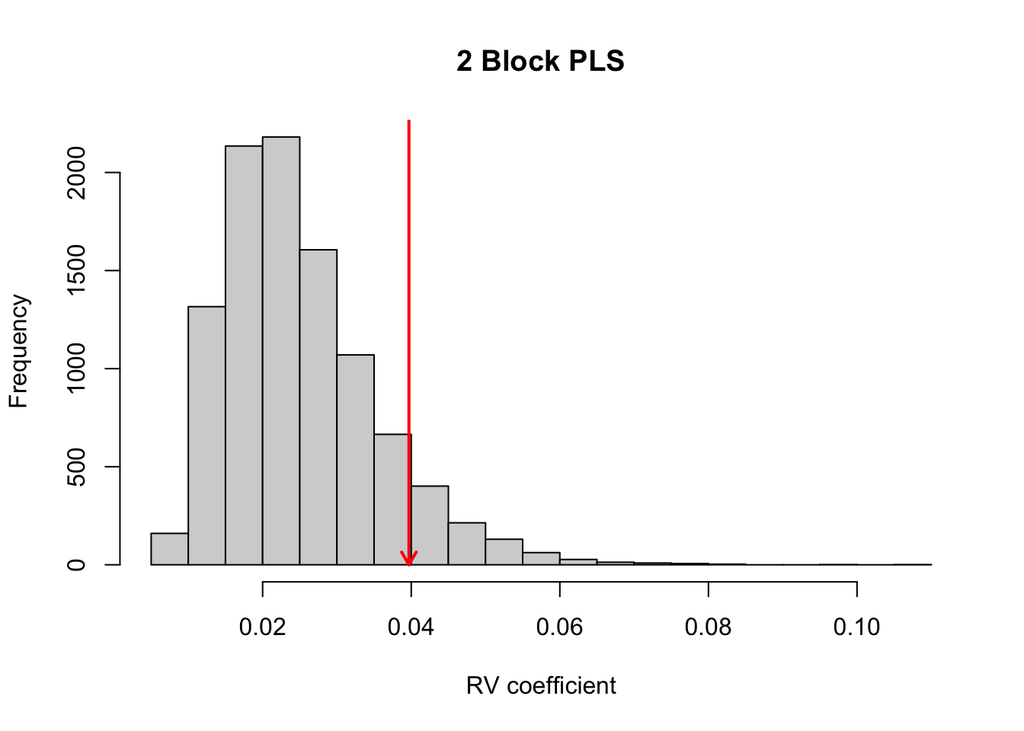

```r
hist(RV.modif, main='2 Block PLS', xlab='RV coefficient', ylab='Frequency', col='lightgray')
arrows(RV.zeca, reps / 4, RV.zeca, 0, length = 0.1, lwd = 2,col='red')
```

### Podemos ainda usar uma função “não muito conhecida” do Julien Claude:

```r
# Precisamos colocar os dados em matrizes, como normalmente já fazíamos...
corio.sobrepo$coords; memb.sobrepo$coords
```

[output not shown]

[output cut: 1738 more lines]

```
##  [8,] -0.09109267 -0.19267437
##  [9,] -0.48122632 -0.02104974
##
## , , female60
##
##              [,1]        [,2]
##  [1,] -0.46933532  0.03868414
##  [2,] -0.19695691  0.15804940
##  [3,]  0.14982183  0.21246052
##  [4,]  0.40399183  0.13877027
##  [5,]  0.23891262 -0.08882884
##  [6,]  0.27822495 -0.13355278
##  [7,]  0.15656422 -0.13436801
##  [8,] -0.08702896 -0.17873979
##  [9,] -0.47419425 -0.01247490
```

[output not shown]

[output cut: 1048 more lines]

```
## , , female59
##
##             [,1]        [,2]
## [1,]  0.01638571  0.30295949
## [2,]  0.27481060 -0.07155031
## [3,]  0.46992616 -0.13050303
## [4,] -0.76112246 -0.10090614
##
## , , female60
##
##              [,1]        [,2]
## [1,] -0.006258385  0.30461920
## [2,]  0.294942636 -0.07150799
## [3,]  0.466426404 -0.13848098
## [4,] -0.755110655 -0.09463022
```

```r
tudo1 <- two.d.array(corio.sobrepo$coords)
tudo2 <- two.d.array(memb.sobrepo$coords)

#### FUNÇÃO DO CLAUDE:
pls<-function(M1, M2)
  {p1<-dim(M1)[2]; p2<-dim(M2)[2]; n<-dim(M1)[1]
  sM12<-svd(var(cbind(M1,M2))[1:p1, (p1+1):(p1+p2)])
  vM12<-var(cbind(M1,M2))[1:p1, (p1+1):(p1+p2)]
  vM21<-var(cbind(M1,M2))[(p1+1):(p1+p2), 1:p1]
  v11<-var(M1)
  v22<-var(M2)
  D<-sM12$d; F1<-sM12$u; F2<-sM12$v
  Rv<-sum(diag(vM12%*%vM21))/sqrt(sum(diag(v11%*%v11))*sum(diag(v22%*%v22)))
  list(Rv=Rv, F1=F1, F2=F2, D=D)}

pls2 <- pls(tudo1, tudo2)
pls2
```

```
## $Rv
## [1] 0.03968988
##
## $F1
##               [,1]         [,2]         [,3]        [,4]        [,5]
##  [1,]  0.006285563  0.035029123 -0.042221609 -0.05953190 -0.22059497
##  [2,]  0.010695726  0.024101787  0.197109079  0.03763735 -0.16304328
##  [3,]  0.017745482 -0.235778537  0.317583796  0.46049119  0.14656001
##  [4,] -0.093592113 -0.270304612 -0.057757406  0.09494462 -0.34591257
##  [5,] -0.591590262  0.416192289 -0.091471613 -0.07016699  0.29189298
##  [6,] -0.093233048 -0.021332225 -0.156837027 -0.17291142 -0.37057457
##  [7,]  0.719513892  0.239512007 -0.010503881 -0.02985613  0.01916864
##  [8,] -0.123294516  0.185365258  0.717806825 -0.11083363 -0.05109923
##  [9,] -0.078034700 -0.557644065  0.055657497 -0.15865278  0.03726016
## [10,]  0.052440699  0.050680749 -0.055734330  0.40425073  0.30212659
```

[output cut: 51 more lines]

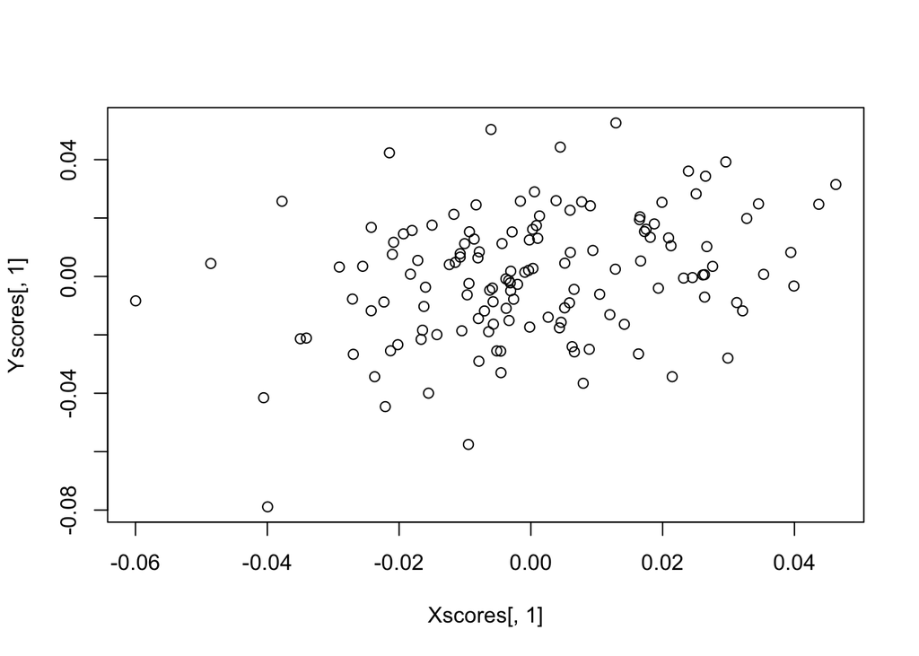

```r
Xscores <- tudo1%*%pls2$F1
Yscores <- tudo2%*%pls2$F2
plot(Xscores[,1], Yscores[,1])
```

```r
cor(Xscores[,1], Yscores[,1])
```

```
## [1] 0.3065411
```

```r
# Calculando-se um p-valor para esse RV:
RvNULL<-numeric()
for (i in 1:999){
  RvNULL[i] <- pls(tudo1[sample(138),], tudo2)$Rv
}
(length(which(RvNULL > pls2$Rv)) + 1) / 1000 #adicionar 1 nos da p-valores que nunca estarão abaixo de 0.0001
```

```
## [1] 0.076
```

$\color{red}{\text{Tentem, agora, com a função de DEAN (Essa opção não existe no help!}}$ $\color{red}{\text{Talvez porque as pessoas que desenvolveram o geomorph gostem mais da "covariance ratio" (Adams, 2016).}}$

```r
geomorph:::pls(tudo1, tudo2, verbose = T, RV = T)
```

```
## $pls.svd
## $pls.svd$d
## [1] 1.290116e-04 7.244032e-05 4.150981e-05 9.230472e-06 6.731609e-19
## [6] 2.726061e-19 1.147009e-19 5.876339e-20
##
## $pls.svd$u
##               [,1]         [,2]         [,3]        [,4]        [,5]
##  [1,]  0.006285563  0.035029123 -0.042221609 -0.05953190 -0.21052157
##  [2,]  0.010695726  0.024101787  0.197109079  0.03763735 -0.15407480
##  [3,]  0.017745482 -0.235778537  0.317583796  0.46049119  0.15245111
##  [4,] -0.093592113 -0.270304612 -0.057757406  0.09494462 -0.35614338
##  [5,] -0.591590262  0.416192289 -0.091471613 -0.07016699  0.29771984
##  [6,] -0.093233048 -0.021332225 -0.156837027 -0.17291142 -0.37048351
##  [7,]  0.719513892  0.239512007 -0.010503881 -0.02985613  0.02419092
##  [8,] -0.123294516  0.185365258  0.717806825 -0.11083363 -0.05510961
##  [9,] -0.078034700 -0.557644065  0.055657497 -0.15865278  0.05062351
## [10,]  0.052440699  0.050680749 -0.055734330  0.40425073  0.30507905
## [11,] -0.232093104 -0.058433906 -0.312051466  0.21329857 -0.23484011
## [12,]  0.128248821 -0.141991569 -0.189147440 -0.10548413  0.34574745
## [13,]  0.007989104 -0.145938336 -0.042996366 -0.21044652  0.37887647
## [14,]  0.069908968  0.084117252 -0.327252023  0.35354837 -0.03844067
## [15,]  0.073467321  0.457508192  0.007915936  0.06043899 -0.23266598
## [16,]  0.060593711  0.081508565 -0.198862447 -0.51514017  0.10142587
## [17,]  0.076716704 -0.150446767  0.118087706 -0.20557443 -0.17696561
## [18,] -0.011768249  0.007854795  0.070674770  0.01398828  0.20311343
##              [,6]         [,7]        [,8]
##  [1,] -0.04221891 -0.265916236  0.01071377
##  [2,]  0.29049366  0.368541982 -0.05662848
##  [3,] -0.17082190 -0.261363949  0.43670817
##  [4,] -0.04120343  0.012969970 -0.20350152
##  [5,]  0.36895025 -0.223094347  0.09219507
##  [6,] -0.09529683 -0.394469782  0.32761577
##  [7,]  0.20754363 -0.330402151  0.00870316
##  [8,]  0.01559390 -0.088425032 -0.11334148
##  [9,]  0.22265765  0.170494955  0.34901998
## [10,] -0.05930021 -0.105465065 -0.30287429
## [11,] -0.16078739 -0.071527948 -0.30649384
## [12,]  0.30540534  0.186092870  0.02658588
## [13,] -0.39691224  0.099705112 -0.13603861
## [14,]  0.22310967  0.099629425  0.14905591
```

[output cut: 636 more lines]

[output not shown]

### Alternativa: **coeficiente CR**

### $$CR = \sqrt{ \frac{tr (\mathbf{S}_{12} \mathbf{S}_{21})} {\sqrt{tr (\mathbf{S}_{11} \mathbf{S}_{11}) tr(\mathbf{S}_{22} \mathbf{S}_{22})}}}$$

```r
#CR para cada partição:
p1 <- dim(tudo1)[2]
p2 <- dim(tudo2)[2]
Nspec <- dim(tudo1)[1]
uns <- rep(1, dim(tudo1)[1])

data.tudo<-cbind(tudo1,tudo2)

#calculando a matriz de variância-covariância...
Scov.m <- var(data.tudo)
Sm1m1 <- var(tudo1)
c.zeros <- length(diag(Sm1m1))
zeros <- rep(0, c.zeros)
diag(Sm1m1) <- zeros
Sm2m2 <- var(tudo2)
c.zeros <- length(diag(Sm2m2))
zeros <- rep(0, c.zeros)
diag(Sm2m2) <- zeros
Sm1m2 <- Scov.m[1:p1, (p1 + 1):(p1+p2)] #isolando a parte da matriz S que descreve a covariância entre os blocos 1 e 2
Sm2m1 <- Scov.m[(p1+1):(p1+p2),1:p1]
CR.zeca <- sqrt(sum(diag(Sm1m2 %*% Sm2m1)) / sqrt(sum(diag(Sm1m1 %*% Sm1m1)) * sum(diag(Sm2m2 %*% Sm2m2))))

CR.zeca
```

```
## [1] 0.2961363
```